# Python implementation of Logistic Regression from Scratch

Author

Khiem Nguyen  
Lecturer in Multiscale Materials  
khiem.nguyen@glasgow.ac.uk

# 1 Foreword

This is the fourth and last part of the assignment. The code presented here has been written with GenAI assistance. I have used GenAI to generate the code. However, I have added some comments and explanations to make the code more readable and to explain the different parts of the code. The code is not perfect, but it serves the purpose of demonstrating how a logistic regression model is implemented from scratch in Python. You can use this code as a reference for your C++ implementation. The code is not optimized for performance, but it is written in a way that is easy to understand and follow.

**NoteFor interested students**

You can visit my GitHub repository to learn more about Machine Learning and Deep Learning: [GitHub: uog-ml](https://github.com/khiemnguyen0407/uog-ml). I have implemented many machine learning algorithms from scratch in Python.

Full code is given in `./src/logistic_regression_demo.py` and also at the end of this file. You can run this code to see how the logistic regression model is implemented on a simple and synthetic dataset.

**Remark 01**

Note that the code does not implement the logistic regression model with regularization. However, the assignment requests you to implement the logistic regression model with regularization.

**Remark 02**

**You can easily add the regularization term to the loss function and the gradient descent update rule.** The mathematical formulation of the logistic regression model with regularization is given in the file `03-maths.html` and `03-maths.pdf`. You can refer to those files to understand how to implement the logistic regression model with regularization in C++.

**Hint** You should try to modify the Python code to include the regularization term in the loss function and the gradient descent update rule. This will give you a better understanding of how the regularization term affects the training process and the final model.

# 2 Implementation of Logistic Regression from Scratch

This section will explain different parts of the code and the mathematical formulation behind the logistic regression model. You can read this section to understand how the mathematics behind the logistic regression model is implemented in the code. See the files `03-maths.html` and `03-maths.pdf` for the mathematical formulation of the logistic regression model and the gradient descent method.

## 2.1 Generating a synthetic dataset

First thing first, we import libraries that we need for the implementation.

```python
import numpy as np
import pandas as pd
import matplotlib.pyplot as plt
from pathlib import Path
from sklearn.utils import shuffle
```

```python
n_per_class = 3
centers = [(2, 2), (2, 7), (5, 4.5), (8, 2), (8, 7)]
n_classes = len(centers)
X = np.zeros((n_per_class * n_classes, 2))
y = np.zeros(n_per_class * n_classes, dtype=int)
variance = 0.5  # Increased variance to create overlap
np.random.seed(42)  # for reproducibility
for class_id, (cx, cy) in enumerate(centers):
    for _ in range(n_per_class):
        # Increased scale (1.2) ensures points cross into other class territories
        x1 = np.random.normal(cx, variance)
        x2 = np.random.normal(cy, variance)
        X[class_id * n_per_class + _, :] = [x1, x2]
        y[class_id * n_per_class + _] = class_id

# Shuffle the dataset so that the model doesn't see classes in perfect blocks during training
X, y = shuffle(X, y, random_state=42)
```

Let us visualize the dataset to see how the classes are distributed in the feature space. We can use a scatter plot to visualize the data points and color them according to their class labels.

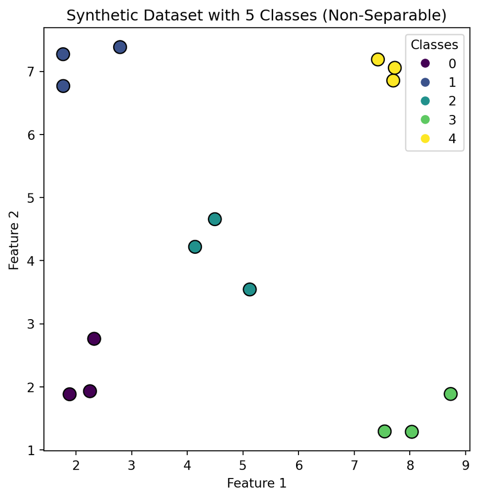

```python
plt.figure(figsize=(6, 6))
scatter = plt.scatter(X[:, 0], X[:, 1], c=y, cmap='viridis', edgecolors='k', s=100)
plt.title("Synthetic Dataset with 5 Classes (Non-Separable)")
plt.xlabel("Feature 1")
plt.ylabel("Feature 2")
plt.legend(*scatter.legend_elements(), title="Classes")
plt.show()
```

Change the `variance` variable to see how the dataset changes. Also, feel free to change the number of points per class `n_per_class` to see how the dataset changes. You should see that as the variance increases, the classes become more and more overlapping, which makes it harder for the logistic regression model to classify the data points correctly.

## 2.2 Implementing the logistic regression model

The logistic regression model is implemented using the softmax function for multi-class classification. The forward propagation function computes the predicted probabilities for each class given the input features, weights, and biases.

```python
def softmax(z):
    exp_z = np.exp(z - np.max(z, axis=1, keepdims=True))
    return exp_z / np.sum(exp_z, axis=1, keepdims=True)
```

Then, we compute the predicted probabilities for each class given the input features, weights, and biases.

```python
def forward_prob(X, W, b):
    z = np.dot(X, W) + b
    return softmax(z)
```

## 2.3 Training the model using gradient descent

The training loop iteratively updates the weights and biases using gradient descent. The loss function used is the cross-entropy loss, and the gradients are computed based on the predicted probabilities and the true labels.

We note that the output of the `forward_prob` function is a matrix of shape `(num_samples, num_classes)`, where each row contains the predicted probabilities for each class for a given sample. For this reason, in order to compute
$$\begin{aligned}
\mathcal{L}(\mathbf{W}, \mathbf{b}) &= -\frac{1}{m} \sum_{i=1}^{m} \sum_{j=1}^{K} y_j^{(i)} \log(\widehat{y}_j^{(i)}) \\[3pt]
&= -\frac{1}{m} \sum_{i=1}^{m} \sum_{j=1}^{K} y_j^{(i)} \log\left(\frac{e^{\mathbf{w}_j \cdot \mathbf{x}^{(i)} + b_j}}{\sum_{k=1}^{K} e^{\mathbf{w}_k \cdot \mathbf{x}^{(i)} + b_k}}\right)
\end{aligned}$$

It is just useful to have the true labels in a one-hot encoded format, which is a binary matrix of shape `(num_samples, num_classes)`, where each row corresponds to a sample and each column corresponds to a class. The value is `1` if the sample belongs to that class and `0` otherwise.

**Note**

Of course in C++ you can use a different data structure to store the one-hot encoded labels, or just simply write multiple loops iterating through the classes and data points. The one-hot encoding is just a convenient way to compute the loss and the gradients because it allows for vectorized operations, but it is not mandatory.

```python
num_samples, num_features = X.shape
num_classes = len(np.unique(y))
# Initialization of weights and biases
W = np.random.randn(num_features, num_classes) * 0.01
b = np.zeros((1, num_classes))
# One-hot encoding of the labels
y_one_hot = (y.reshape(-1, 1) == np.arange(num_classes).reshape(1, -1)).astype(np.double)
print(y_one_hot.shape)  # (250, 5 classes)

# Print the first 3 one-hot encoded labels to verify
# Note that one row corresponds to one sample, and the columns
# correspond to the classes.
print("First 3 one-hot encoded labels:")
print(y_one_hot[3])
# The value is 1 if the sample belongs to that class and 0 otherwise.
```

```
(15, 5)
First 3 one-hot encoded labels:
[0. 0. 0. 0. 1.]
```

Now, we can write the training loop to update the weights and biases using gradient descent. The gradients are computed based on the predicted probabilities and the true labels, and the weights and biases are updated accordingly. All of us have seen this training loop before when we write C++ code for training a linear regression model. The key difference here is that we are using the softmax function to compute the predicted probabilities for each class, and we are using the cross-entropy loss function to compute the loss and the gradients.

**NoteTerminology: Forward pass and Backward pass**

For those students who will proceed to study machine learning in the future, you will see that this training loop is very similar to the training loop used in more complex models such as neural networks. The main difference is that in neural networks, we have multiple layers of weights and biases, and we need to compute the gradients for each layer using backpropagation. However, the overall structure of the training loop remains the same, which is to compute the predicted probabilities, compute the loss, compute the gradients, and update the weights and biases.

The terminology “forward pass” and “backward pass” is commonly used in the context of neural networks, but it can also be applied to logistic regression. The forward pass refers to the computation of the model’s output (predicted probabilities) given the input features and the current weights and biases. The backward pass refers to the computation of the gradients of the loss function with respect to the weights and biases, which is used to update the weights and biases during training. In logistic regression, we can think of the forward pass as computing the predicted probabilities using the softmax function, and the backward pass as computing the gradients based on the predicted probabilities and the true labels.

```python
lr = 0.05           # learning rate
epochs = 500       # number of iterations for training
convergence_threshold = 1e-3  # threshold for convergence
for epoch in range(epochs):
    # Forward pass: compute predicted probabilities
    probs = forward_prob(X, W, b)
    # Compute the error between predicted probabilities and true labels
    error = probs - y_one_hot   # this is possible because both
                                # `probs` and `y_one_hot` have the same
                                # shape (num_samples, num_classes)

    #----------------------------------------------------------------------
    # Backward propagation: compute gradients and update weights and biases
    #----------------------------------------------------------------------
    # Just write down the maths to see how to compute the gradients.
    # You will see that it is just a matter of matrix multiplication
    # and summation and it reflects the mathematical formulation of
    # the logistic regression model and the cross-entropy loss function
    # given in the file `03-maths.html` and `03-maths.pdf`.

    # dW.shape = (num_features, num_classes)
    dW = (1 / num_samples) * np.dot(X.T, error)
    # db.shape = (1, num_classes)
    db = (1 / num_samples) * np.sum(error, axis=0, keepdims=True)

    # Update weights and biases using gradient descent
    W -= lr * dW
    b -= lr * db

    # We monitor the training process by printing the loss every 100 epochs
    if epoch % 100 == 0:
        # Compute the cross-entropy loss
        # We add the small value `1e-9` to the predicted probabilities
        # to avoid taking the log of zero, which can happen if the model
        # is very confident about a wrong prediction. This is a common
        # practice to ensure numerical stability when computing the loss.

        loss_last_epoch = loss if epoch > 0 else None
        loss = -np.mean(np.sum(y_one_hot * np.log(probs + 1e-9), axis=1))
        print(f"Epoch {epoch}: Loss {loss:.4f}")

        # Convergence criterion: if the loss is very small, we can stop training.
        # This is just a simple convergence criterion, and you can use other
        # criteria such as the change in loss or the change in weights and biases.
        if loss_last_epoch is not None \
            and abs(loss_last_epoch - loss) < convergence_threshold:
            print(f"Converged at epoch {epoch}")
            break

W_final, b_final = W, b
```

```
Epoch 0: Loss 1.6066
Epoch 100: Loss 0.6753
Epoch 200: Loss 0.5570
Epoch 300: Loss 0.4884
Epoch 400: Loss 0.4399
```

This is really the end of the training process. We have trained the logistic regression model and obtained the final weights and biases. We can now use these weights and biases to make predictions on new data points or to visualize the decision boundaries of the model.

## 2.4 Make prediction on the training data

Before we test our model on unseen data, let us first make a prediction on the training data to see how well the model has learned to classify the training data. We can use the `forward_prob` function to compute the predicted probabilities for each class given the input features, weights, and biases. We can then print the predicted probabilities and the predicted class for each data point in the training set.

```python
# Compute predicted probabilities for each class for the training data
predicted_probs_train = forward_prob(X, W_final, b_final)
# Print predicted probabilities and predicted class for each data point in the training set
for i, probs in enumerate(predicted_probs_train):
    predicted_class = np.argmax(probs)
    print(f"Data point: {X[i]}, True label: {y[i]}, Predicted class: {predicted_class}")
```

```
Data point: [7.54598796 1.29384815], True label: 3, Predicted class: 3
Data point: [8.0337641  1.28762591], True label: 3, Predicted class: 3
Data point: [2.24835708 1.93086785], True label: 0, Predicted class: 0
Data point: [7.42450321 7.18784901], True label: 4, Predicted class: 4
Data point: [1.76829115 6.76713512], True label: 1, Predicted class: 1
Data point: [4.49358444 4.65712367], True label: 2, Predicted class: 4
Data point: [1.88292331 1.88293152], True label: 0, Predicted class: 0
Data point: [2.32384427 2.76151493], True label: 0, Predicted class: 0
Data point: [7.69968066 6.85415313], True label: 4, Predicted class: 4
Data point: [1.76526281 7.27128002], True label: 1, Predicted class: 1
Data point: [4.13754108 4.21885624], True label: 2, Predicted class: 2
Data point: [8.73282438 1.88711185], True label: 3, Predicted class: 3
Data point: [7.72780864 7.05546129], True label: 4, Predicted class: 4
Data point: [2.78960641 7.38371736], True label: 1, Predicted class: 1
Data point: [5.12098114 3.54335988], True label: 2, Predicted class: 2
```

Let us then compute the accuracy of the model on the training data to see how well the model has learned to classify the training data. The accuracy is computed as the number of correct predictions divided by the total number of predictions.

```python
# Compute predicted classes for the training data
predicted_classes_train = np.argmax(predicted_probs_train, axis=1)
# Compute accuracy on the training data
accuracy_train = np.mean(predicted_classes_train == y)
print(f"Accuracy on the training data: {accuracy_train:.4f}")
```

```
Accuracy on the training data: 0.9333
```

Change the variance `variance`, the number of epochs to a larger value (e.g., `epochs = 2000`) and learning rate `lr` and see how the accuracy on the training data changes. You should see that the accuracy increases as the number of epochs increases, which indicates that the model is learning to classify the training data better.

## 2.5 Make prediction on unseen data

Let us make a prediction on a new data point. We can use the `forward_prob` function to compute the predicted probabilities for each class given the input features, weights, and biases. Particularly, we shall compute the predicted probabilities for $3$ data points that are not in the training set. We can then print the predicted probabilities and the predicted class for each of these data points.

```python
# Generate 3 new data points that are not in the training set
new_data_points = np.array([[3, 3], [3, 6], [6, 4]])
# Compute predicted probabilities for each class for the new data point
predicted_probs = forward_prob(new_data_points, W_final, b_final)
# Print predicted probabilities and predicted class for each new data point
for i, probs in enumerate(predicted_probs):
    predicted_class = np.argmax(probs)
    print(f"Data point: {new_data_points[i]}, Predicted class: {predicted_class}")
```

```
Data point: [3 3], Predicted class: 0
Data point: [3 6], Predicted class: 1
Data point: [6 4], Predicted class: 4
```

## 2.6 Full Python code

**Note**

Again, this code is fully generated by GenAI. I have only made some minor edits to make it more readable and to add some comments. The code is not perfect, but it serves the purpose of demonstrating how a logistic regression model is implemented from scratch in Python.

```python
import numpy as np
import pandas as pd
import matplotlib.pyplot as plt
from pathlib import Path
from sklearn.utils import shuffle

#===================
# 1. DATA GENERATION (using variance to create non-separable classes)
#===================
def generate_overlapping_data(n_per_class=5):
    """Generates 5 classes with 5 points each. Increased variance creates overlap."""
    data = []
    centers = [(2, 2), (2, 7), (5, 4.5), (8, 2), (8, 7)]
    variance = 0.5  # Increased variance to create overlap
    np.random.seed(42)  # for reproducibility
    for class_id, (cx, cy) in enumerate(centers):
        for _ in range(n_per_class):
            # Increased scale (1.2) ensures points cross into other class territories
            x1 = np.random.normal(cx, variance)
            x2 = np.random.normal(cy, variance)
            data.append([x1, x2, class_id])

    df = pd.DataFrame(data, columns=['feat1', 'feat2', 'label'])
    # Shuffle so the model doesn't see classes in perfect blocks during training
    return shuffle(df, random_state=42).reset_index(drop=True)

#==============
# 2. MODEL MATH
#==============
def softmax(z):
    # keepdims=True ensures that the output has the same shape as z,
    # which is important for broadcasting during the division
    exp_z = np.exp(z - np.max(z, axis=1, keepdims=True))
    return exp_z / np.sum(exp_z, axis=1, keepdims=True)

def forward_prop(X, W, b):
    z = np.dot(X, W) + b
    return softmax(z)

#=================
# 3. TRAINING LOOP
#=================
def train_model(X, y, lr=0.05, epochs=2000):
    num_samples, num_features = X.shape
    num_classes = len(np.unique(y))

    # Initialization
    W = np.random.randn(num_features, num_classes) * 0.01
    b = np.zeros((1, num_classes))
    y_oh = pd.get_dummies(y).values

    print(f"Training on {num_samples} points...")
    for epoch in range(epochs):
        # Forward pass: compute predicted probabilities
        probs = forward_prop(X, W, b)

        # Gradient of loss function w.r.t. weights and biases
        error = probs - y_oh
        dW = (1 / num_samples) * np.dot(X.T, error)
        db = (1 / num_samples) * np.sum(error, axis=0, keepdims=True)

        # Update
        W -= lr * dW
        b -= lr * db

        if epoch % 500 == 0:
            loss = -np.mean(np.sum(y_oh * np.log(probs + 1e-9), axis=1))
            print(f"Epoch {epoch}: Loss {loss:.4f}")

    return W, b

#=========================================
# 4. VISUALIZATION (Decision Boundaries)
#=========================================
def plot_boundaries(X, y, W, b, filename):
    plt.figure(figsize=(10, 8))

    # Create a grid of points covering the feature space
    x_min, x_max = X[:, 0].min() - 1, X[:, 0].max() + 1
    y_min, y_max = X[:, 1].min() - 1, X[:, 1].max() + 1
    xx, yy = np.meshgrid(np.arange(x_min, x_max, 0.05),
                         np.arange(y_min, y_max, 0.05))

    # Predict for every point in the grid
    grid_points = np.c_[xx.ravel(), yy.ravel()]
    probs = forward_prop(grid_points, W, b)
    predictions = np.argmax(probs, axis=1)
    predictions = predictions.reshape(xx.shape)

    # Plot background colors
    plt.contourf(xx, yy, predictions, alpha=0.3, cmap='viridis')

    # Plot the original data points
    scatter = plt.scatter(X[:, 0], X[:, 1], c=y, cmap='viridis', edgecolors='k', s=40)

    plt.title("Multinomial Logistic Regression: Decision Boundaries (Non-Separable)")
    plt.xlabel("Feature 1")
    plt.ylabel("Feature 2")
    plt.savefig(filename)
    plt.close()
    print(f"Boundary plot saved to {filename}")

#==========
# EXECUTION
#==========
Path("./data").mkdir(exist_ok=True)

df = generate_overlapping_data(50)
X_train = df[['feat1', 'feat2']].values
y_train = df['label'].values

# Run Training
W_final, b_final = train_model(X_train, y_train)

# Generate Visual
plot_boundaries(X_train, y_train, W_final, b_final, "./data/decision_boundaries.png")
```